# Trabajo Infantil

Eduardo Gaitán Escalante Eric Oziel Hernandez Salinas

2022-07-01

# Trabajo Infantil en México 2019: una aproximación a sus determinantes esenciales.

## Introducción

En el presente documento se aspira realizar una investigación sobre el trabajo infantil en México, tomando en cuenta algunas variables analizadas para la población de 5 a 17 años obtenidas de los microdatos de la Encuesta Nacional de Trabajo Infantil (ENTI 2019) del **INEGI.** Por lo que para analizar la base filtraremos de la base original variables de corte socioeconómico e intrafamiliar determinantes para la Condición de Trabajo Infantil (CTI) como variable dependiente, así como, las omisiones, datos nulos, cuestionarios incompletos y categorías no especificadas, hasta conformar una submuestra.

Segundo, se realizará una descripción estadística de la base de datos y también de la submuestra, asi como un análisis de la muestra para que podamos observar la estructura y distribución de los datos y a que nivel representativo llegamos. Posteriormente, integramos un modelo logit multinomial con las variables seleccionadas, donde se analice la condición de ocupación de los infantes y con regresores socioeconómicos e intrafamiliares que consideramos tienen un mayor impacto en la determinación de su condición de ocupación, ya sea no permitida, peligrosa o no permitida y permitida.

Finalmente se concluye con algunos resultados y reflexiones sobre el trabajo infantil en México en 2019, los retos y propuestas a implementar.

## Trabajo infantil en México y revisión de la literatura

En México el trabajo infantil en una definición amplia, es definido por el INEGI como aquella en la que “Los niños y niñas en formas de trabajo prohibidas, en tipos de trabajo que es preciso eliminar por ser social y moralmente indeseables” en este trabajo retomamos esta definición para la variable dependiente.

De acuerdo con Bando, López-Calva y otros (2005), es relevante para el trabajo infantil (en su investigación de población indígena en México) considerar las características familiares, en especial la edad y el tamaño de la familia, además de ser un factor que responde a los salarios de los adultos. Asimismo, las familias más pobres son las que demandan más trabajo infantil, situación que los hace propensos a dejar la escuela.

Por su parte, desde otra corriente de pensamiento Becker (1991:137) menciona que, las familias deciden como dividir el ingreso entre la cantidad de hijos lo que también determina su estatus en el trabajo o la asistencia escolar, cómo la oferta laboral de los niños se determina en función de la calidad y cantidad del ingreso de acuerdo con el número de hijos.

Para el caso de México los informes sobre condiciones deplorables de trabajo infantil es reciente, resaltando las actividades pertinentes encaminadas a combatir las peores formas de trabajo infantil, desde las cuales se trata de ratificar en el T-MEC entre México, Estados Unidos y Canadá que se apoya con la enmienda de la Ley General de Educación, en busca de fortalecer el acceso a la educación para niños provenientes de grupos marginados.

Por parte del gobierno se combate desde la forma jurídica con demandas a la trata de menores, así como creando una nueva protección de niñas, niños y adolescentes, con propósitos de eliminar el trabajo infantil para 2019-2024. Además, incentivando en el levantamiento de la Encuesta Nacional de Trabajo Infantil 2019( ENTI) que mejora y complementa la información sobre las condiciones múltiples que determinan la incorporación de infantes al trabajo infantil; además de ser primordial para el tratamiento de los datos a utilizar en esta investigación. No obstante, los infantes mexicanos entre las peores formas de ocupación de trabajo infantil es la explotación sexual con fines comerciales, tareas en la agricultura por diversas condiciones no aptas para menores, entre otros (Bureau of International Labor Affairs, 2020).

En la evidencia para México Pedro Orraca (2014), encuentra que el orden de nacimiento de los hijos, las discrepancias entre los hijos y la asignación de tiempo entre tareas escolares y laborales que mayormente trabajan a no asisten a la escuela también son relevantes para ver si los infantes están dentro del trabajo infantil.

Además, Alcaraz et al. (2010) encuentran relevante en sus resultados que una reducción significativa de las remesas causa un incremento en el trabajo infantil, aumentando la deserción escolar y reafirmando la importancia del ingreso de los adultos en el hogar.

Para la OIT el trabajo infantil es “aquel que priva a los niños de su infancia, de su potencial y de su dignidad, y es perjudicial para su desarrollo físico y mental” (OIT, 2002, p. 16)

## Hipótesis

Por su parte, analizando el modelo pasamos a la formación de la prueba de hipótesis del modelo multinomial, en la que la condición de trabajo infantil bajo las tres categorías a señalar es que en nuestra hipótesis nula sea igual a 0.

$$H0: \beta_1,\beta_2,\beta_3 =
0$$

Mientras la hipótesis alternativa responde a que las betas seleccionadas sean distintas de cero.

$$H1: \beta_1,\beta_2,\beta_3 \neq 0$$

## Descripción de la base

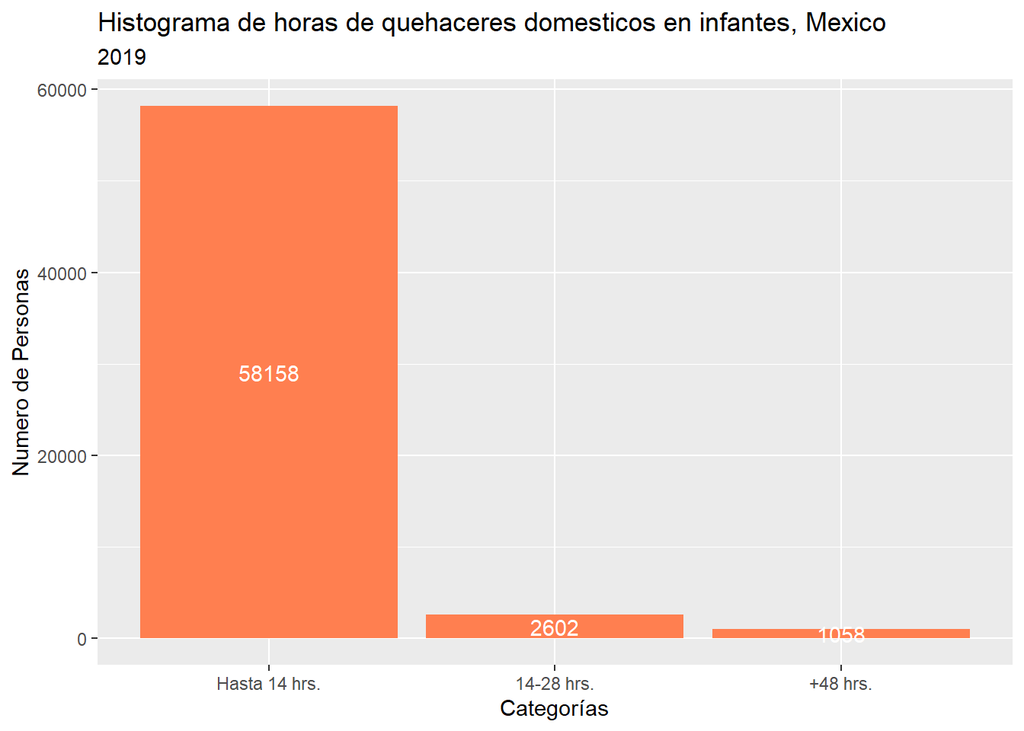

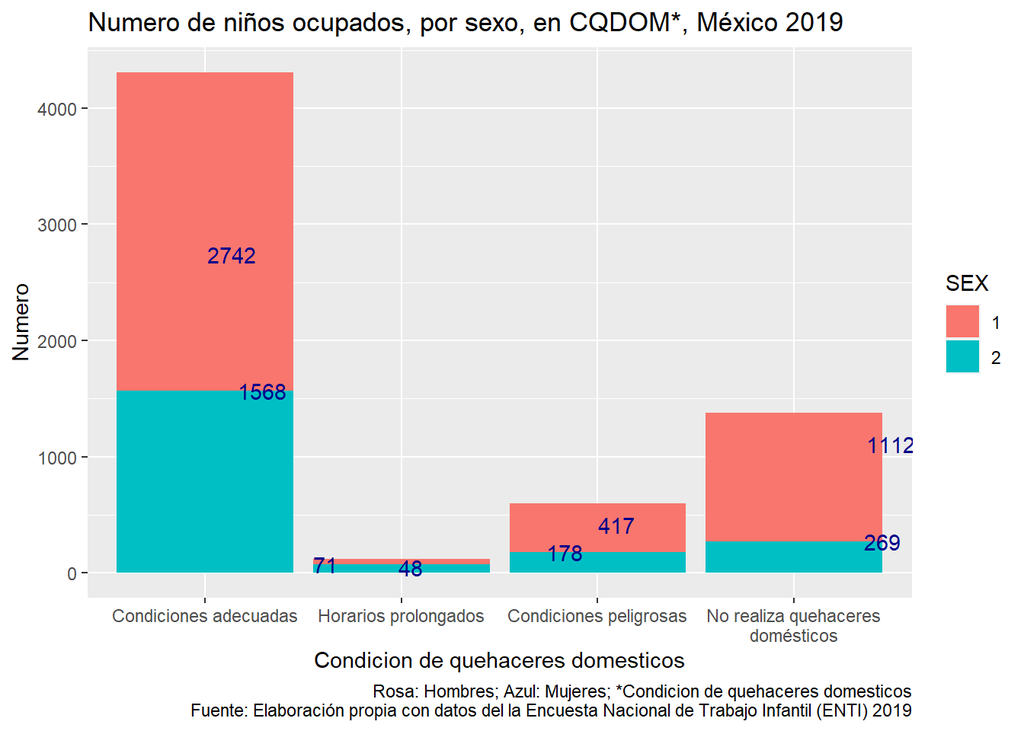

En la segunda gráfica podemos ver más claramente como en la condición de quehaceres domésticos tanto hombres como mujeres se encuentran en quehaceres domésticos con condiciones adecuadas, sin embargo es preocupante observar que aun más de 500 infantes de la submuestra se encuentran en horarios prolongados o condiciones peligrosas. Finalmente podemos ver que las mujeres son menos propensas a estar exentas de trabajo domestico.

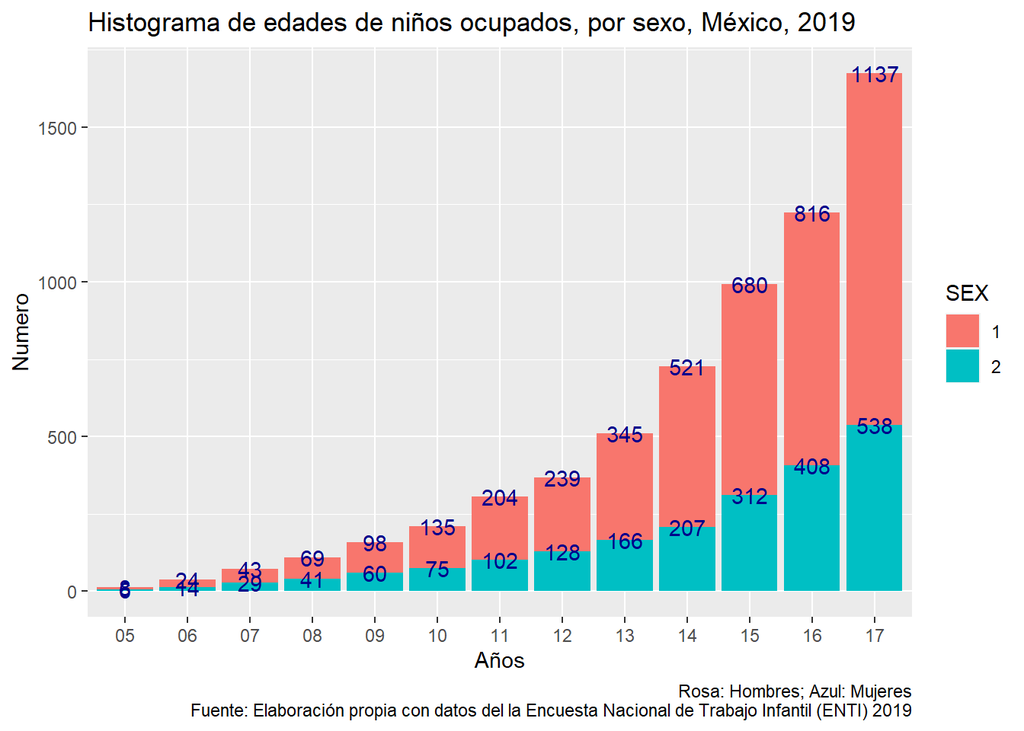

La tercera gráfica nos demuestra la relación de la edad de los infantes con su condición de ocupación. Entre mayor edad, existe una mayor cantidad de niños ocupados, es decir que la economía requiere de fuerza de trabajo infantil y cada que se acercan a su edad propia para trabajar como adultos, se demanda mayor cantidad del mismo, aun en condiciones impropias.

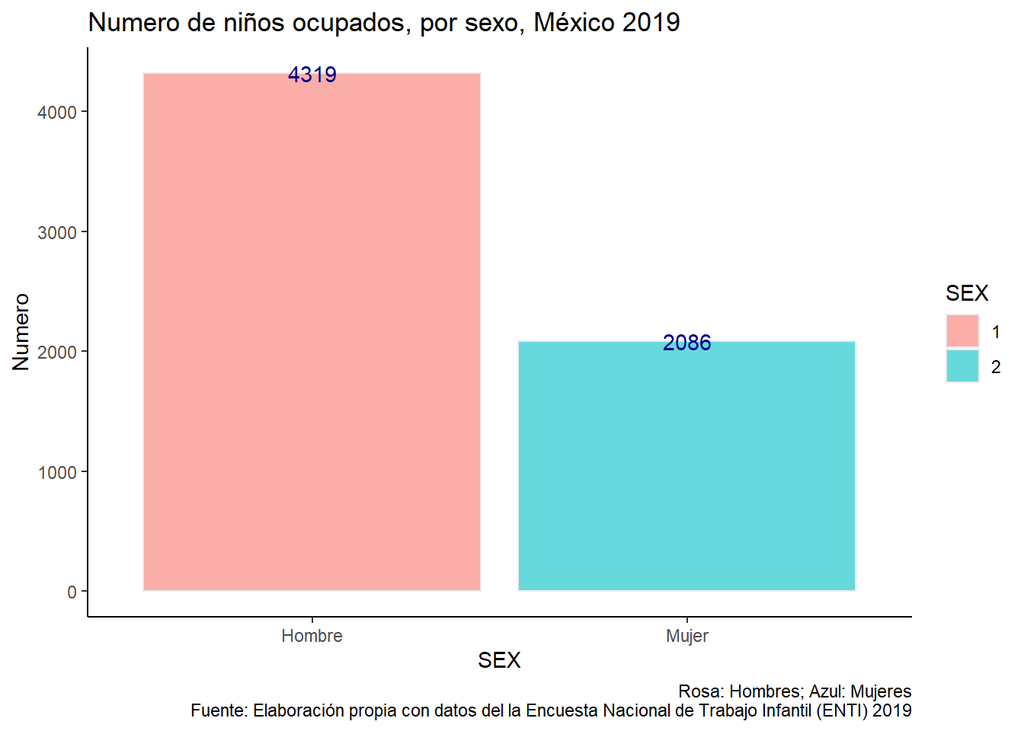

Finalmente observamos que la mayor parte de los infantes que trabaja son varones, mientras que las mujeres infantes ocupadas representan solo la mitad. Esto podría indicarnos la tendencia de los hogares mexicanos a otorgar el papel de proveedor y trabajador a los varones sobre las mujeres y en consecuencia a solicitarlos para el trabajo.

## Procesamiento de los datos y explicación de la submuestra

Para obtener la submuestra, filtramos por condición de cuestionario completado y por condición de ocupación para poder ver cuales son los infantes que contestaron el cuestionario, que son ocupados, filtramos también los infantes que no especifican su escolaridad, su sector de actividad, su nivel de ingresos, y la persona para la que trabaja.

|  | vars | n | mean | sd | median | trimmed | mad | min | max | range | skew | kurtosis | se | Q0.25 | Q0.75 |
| --- | --- | --- | --- | --- | --- | --- | --- | --- | --- | --- | --- | --- | --- | --- | --- |
| EDA1 | 1 | 6405 | 2.546292 | 0.6085386 | 3 | 2.634342 | 0.0000 | 1 | 3 | 2 | -0.9920107 | -0.0457102 | 0.0076038 | 2 | 3 |
| SEX* | 2 | 6405 | 1.325683 | 0.4686661 | 1 | 1.282146 | 0.0000 | 1 | 2 | 1 | 0.7437693 | -1.4470331 | 0.0058560 | 1 | 2 |
| ASIS | 3 | 6405 | 1.216237 | 0.4120892 | 1 | 1.145171 | 0.0000 | 1 | 3 | 2 | 1.3849349 | -0.0603790 | 0.0051491 | 1 | 1 |
| CTI | 4 | 6405 | 1.411085 | 0.9173030 | 1 | 1.183805 | 0.0000 | 1 | 4 | 3 | 1.9261667 | 2.0695560 | 0.0114618 | 1 | 1 |
| CQDOM | 5 | 6405 | 1.851210 | 1.2674271 | 1 | 1.689171 | 0.0000 | 1 | 4 | 3 | 0.9160819 | -1.0190056 | 0.0158367 | 1 | 3 |
| C_OCU | 6 | 6405 | 2.470414 | 0.6215025 | 3 | 2.548683 | 0.0000 | 1 | 3 | 2 | -0.7444328 | -0.4395457 | 0.0077657 | 2 | 3 |
| R_DEF_CB* | 7 | 6405 | 1.000000 | 0.0000000 | 1 | 1.000000 | 0.0000 | 1 | 1 | 0 | NaN | NaN | 0.0000000 | 1 | 1 |
| N_ESC | 8 | 6405 | 4.250898 | 1.4233381 | 4 | 4.330342 | 1.4826 | 1 | 7 | 6 | -0.4046488 | -0.9903956 | 0.0177848 | 3 | 5 |
| CTI2 | 9 | 6405 | 1.415457 | 0.9224683 | 1 | 1.189268 | 0.0000 | 1 | 4 | 3 | 1.9009791 | 1.9585441 | 0.0115264 | 1 | 1 |

Por otra parte la mediana de la asistencia a la escuela (ASIS) es 1 y la media 1.21, lo que nos indica que en promedio la mayoría de los niños que trabajan también asisten a la escuela, esto demuestra que no siempre la relación de trabajo infantil tiene que ser negativa con la de asistencia a la escuela.

La condición de trabajo infantil (CTI), nuestra variable indicativa de si la situación de ocupación de un infante es apropiada o no, tiene una media de 1.41, y una mediana de 1 lo que indica que en promedio los infantes están ocupados en condiciones no permitidas y pocos están fuera del trabajo infantil.

En la condición de ocupación los datos son preocupantes, pues la mayoría de los infantes ocupados están en en ocupación no permitida o en ocupación peligrosa con una media de 2.47 y mediana de 3.

El nivel de escolaridad común entre los individuos de la submuestra es en promedio 4.25 lo que esta entre el nivel de secundaria incompleta (4) y secundaria completa (5).

La variable transformada CTI2 no presenta grandes cambios significativos en su distribución al unir dos de sus categorías y sin embargo presenta un mejor ajuste al modelo.

## Modelo Logístico Multinomial

Para este trabajo planteamos un modelo de regresión logística de la siguiente forma:

$$Y =P(y_i = j | X_i) = \frac{e^{x_iB_j}}{1 +
e^{x_iB_1}+e^{x_iB_2}+e^{x_iB_3}} ;
j\in {0,1,2,3}$$

En esta forma funcional se aprecia que el modelo logístico multinomial integra 3 categorías para la variable dependiente llamada Condición de Trabajo Infantil (CTI), donde especifican si el infante está en:

1. Solo en ocupación permitida
2. Solo en quehaceres domésticos en condiciones no adecuadas o en ocupación no permitida.
3. Fuera de trabajo infantil.

|  | (Intercept) | EDA1 | SEX2 | ASIS | CQDOM | C_OCU | N_ESC |
| --- | --- | --- | --- | --- | --- | --- | --- |
| Coeficientes | -4.3025531 | 0.7424355 | 0.5623580 | 0.7716824 | 0.6686342 | -1.3261704 | 0.2670257 |
| E. Estandar | 0.2512208 | 0.1969050 | 0.0928015 | 0.0979253 | 0.0334265 | 0.1929034 | 0.0447553 |
| Estadistico Z | -17.1265809 | 3.7705276 | 6.0597928 | 7.8803151 | 20.0031334 | -6.8747917 | 5.9663476 |
| p value | 0.0000000 | 0.0001629 | 0.0000000 | 0.0000000 | 0.0000000 | 0.0000000 | 0.0000000 |

Fuente: Elaboración propia. | Nota: El grupo de referencia corresponde a la categoría en quehaceres domésticos en condiciones no adecuadas y en ocupación no permitida

En los resultados para los coeficientes del modelo podemos ver que la edad es una variable que impacta en la condición de trabajo infantil de manera que a mayor sea la edad, mayor es la probabilidad de que estén en alguna ocupación o fuera del trabajo infantil.

## Resultados

### Efectos Marginales

|  | (Intercept) | EDA1 | SEX2 | ASIS | CQDOM | C_OCU | N_ESC |
| --- | --- | --- | --- | --- | --- | --- | --- |
| 3 | 0.0135340 | 2.101046 | 1.7548055 | 2.1634030 | 1.9515701 | 0.2654921 | 1.3060741 |
| 4 | 0.0002114 | 25830.379734 | 0.9004751 | 0.4228002 | 0.5381463 | 0.0000008 | 0.7220516 |

## Conclusiones finales

Basado en el estudio de la ENTI, podemos rescatar que, aun existen una gran cantidad de infantes que tienen condiciones laborales que moralmente y jurídicamente deben desaparecer, por ello se propone mayores refuerzos especialmente para políticas publicas enfocadas a las familias numerosas en cuanto a asistencia económico-social, pues como se ha visto estos factores son los mayores determinantes a la hora de que los niños se encuentren en un ambiente pleno o se inserten al estudio, y si llegaran a estar en una ocupación, que esta fuera digna y sin condiciones de peligro.

Otra propuesta es la de el fomento a la educación básica, pues como ya se ha dicho esta variable también es importante a la hora de y media superior pues la mayor parte de los infantes que laboran están en un nivel educativo de secundaria o secundaria incompleta.

Además se debe de considerar los factores estructurales del sistema económico y sus contradicciones, así como el hecho de que exista una por trabajo infantil en las actividades diarias de las familias, tanto en quehaceres como en trabajos fuera del hogar los infantes aun necesitan ir a trabajar ya sea para mantener sus estudios (o los de familiares), o mantener sus hogares. en la sociedad mexicana aun existe una gran demanda de fuerza de trabajo infantil lo que implica a su vez mayor explotación infantil. Para asegurar a las personas una vida digna se debe también encontrar las causas que impiden este logro para poder atacarlas de mejor manera.

### Referencias

- Alcaraz, C., & Chiquiar, J. (2014). Remesas, Asistencia Escolar y Trabajo Infantil en México [Libro electrónico]. Banxico. Recuperado de: https://www.banxico.org.mx/publicaciones-y-prensa/documentos-de-investigacion-del-banco-de-mexico/%7BDC143853-791B-A525-7D13-73672A3B2DDC%7D.pdf
- Bando R., Lopez-Calva L. , Patrinos H., (2005). *Child Labor, School Attendance, and Indigenous Households: Evidence from Mexico*. Banco Mundial. Recuperado de: https://openknowledge.worldbank.org/handle/10986/8921?locale-attribute=es
- Becker, G. (1991). A treatise on the family, Harvard University Press, Boston , p. 137.
- Bureau of International Labor Affairs. (2020), *2020 Findings on the Worst Forms of Child Labor.* Estados Unidos. Recuperado de: https://ahifores.com/wp-content/uploads/2021/04/Hallazgos-de-2019-sobre-las-peores-formas-de-trabajo-infantil-Mexico.pdf
- Hlavac, Marek (2022). stargazer: Well-Formatted Regression and Summary Statistics Tables. R package version 5.2.3. https://CRAN.R-project.org/package=stargazer
- INEGI. (2020), *Encuesta Nacional de Trabajo Infantil (ENTI) 2019. Presentación de Resultados.* México. Recuperado de: https://www.inegi.org.mx/contenidos/programas/enti/2019/doc/enti_2019_presentacion_resultados.pdf
- INEGI. (2019), *Encuesta Nacional de Trabajo Infantil 2019.* Microdatos. Catalogo de Datos. Recuperado de: https://www.inegi.org.mx/contenidos/programas/enti/2019/microdatos/enti_2019_fd.pdf
- INEGI. (2019), *Encuesta Nacional de Trabajo Infantil 2019.* Microdatos. Recuperado de: https://www.inegi.org.mx/programas/enti/2019/#Microdatos
- Orraca, P. (2014) El trabajo infantil en México y sus causas, problemas de desarrollo. volúmen 45, p. 113-137. Recuperado de: https://www.sciencedirect.com/science/article/pii/S0301703614708788
- Vladez, M. (2018). *Trabajo en la infancia en los ámbitos doméstico y extradoméstico: una aproximación desde las características de los hogares.* México 2015 - ProQuest. (2018, julio). COLMEX. Recuperado de: https://www.proquest.com/openview/de424e4d4269e0f0b62fb251c007d392/1?pq-origsite=gscholar&cbl=18750&diss=y
- Torres-Reyna, O. (2014). *Logit, Probit and Multinomial Logit models in R*. Recuperado de: https://dss.princeton.edu/training/LogitR101.pdf